# Relatório: 2ª Rodada Laboratório 1

Joaquim e Isabelle

19-11-2023

# 1. Introdução

Este trabalho propõe uma análise das experiências dos turistas motivados por produções audiovisuais, explorando como essas influências impactam suas motivações, expectativas e percepções durante a vivência do turismo como experiência de lazer.

Ao delinear os fundamentos teóricos sobre o turismo induzido pelo audiovisual, abordamos concepções, práticas dos viajantes. Focamos especialmente no “turista motivado por produções audiovisuais”, buscando compreender as dinâmicas subjacentes a suas escolhas de destinos e as consequências dessas experiências.

#### 1.1 Objetivos Gerais do estudo

Compreender a motivação dos turistas para visitar determinada localidade influenciados pelo audiovisual.

#### 1.2 Objetivos Específicos

- Fazer uma análise por grupo de entrevistados;
- fazer uma análise estatística da pesquisa.

# 2 Metodologia

O presente estudo busca uma compreensão aprofundada das motivações dos turistas ao visitarem uma localidade específica, com especial ênfase na influência do audiovisual.

##### 1. Tratamento do Banco de Dados:

Inicialmente, o banco de dados, coletado pelo nosso cliente, passou por um processo de tratamento. Essa etapa foi crucial para garantir a integridade e relevância dos dados, permitindo uma análise estatística mais precisa.

##### 2. Análise Exploratória:

Utilizando estatísticas descritivas e gráficos para obter e apresentar insights preliminares sobre as variáveis presentes no banco de dados. Isso proporcionou uma compreensão inicial da distribuição e tendências dos dados, destacando padrões e anomalias que orientaram as etapas subsequentes da pesquisa.

##### 3. Testes Qui-Quadrado:

Para investigar as relações entre a variável de interesse, representada pelo grupo dos participantes, e outras variáveis relevantes, empregamos testes qui-quadrado. Com isso determinamos se existem associações significativas entre as variáveis, revelando fatores que influenciam a motivação dos turistas. Os resultados orientaram a seleção das variáveis mais relevantes para o modelo de regressão logística.

##### 4. Modelo de Regressão Logística:

Com base nas variáveis identificadas como estatisticamente significativas nos testes qui-quadrado, desenvolvemos um modelo de regressão logística explorando a relação entre as variáveis independentes selecionadas e a variável dependente de interesse.

# 3 Resultados

Os resultados são apresentados de maneira abrangente, com gráficos, testes estatísticos para avaliação das variáveis e tabelas que descrevem os dados no geral. Além disso, empregamos a regressão logística para compreendermos de forma mais intuitiva a relação das variáveis explicativas com a variável de interesse.

## 3.1 Análise exploratória - Estatísticas descritivas

### Gráfico 1: Turistas classificados segundo o grupo

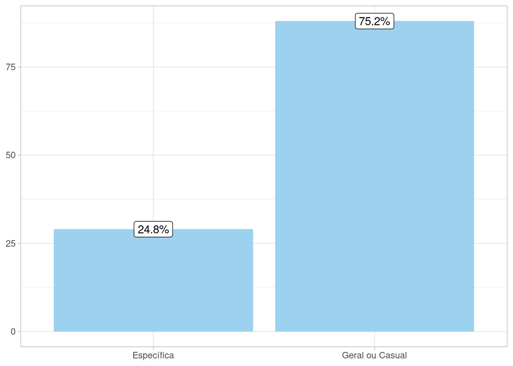

### Gráfico 2: Sexo por grupo

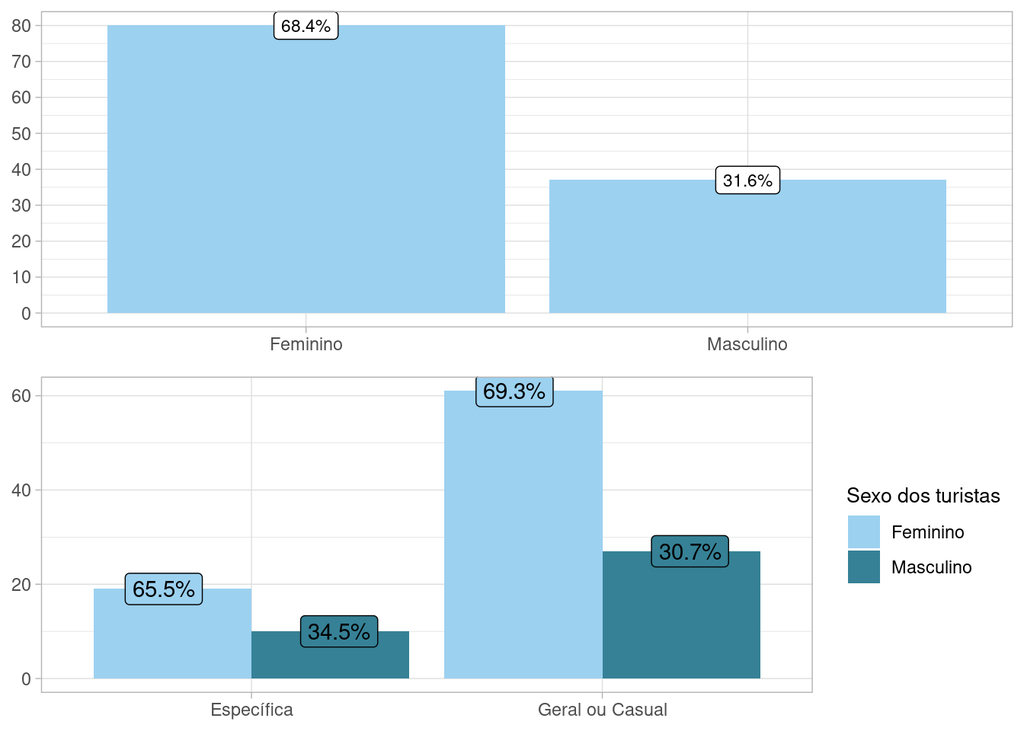

```
## [1] "Valor-p do teste qui-quadrado: 0.8796 ."
```

### Gráfico 3: Faixa etária por grupo

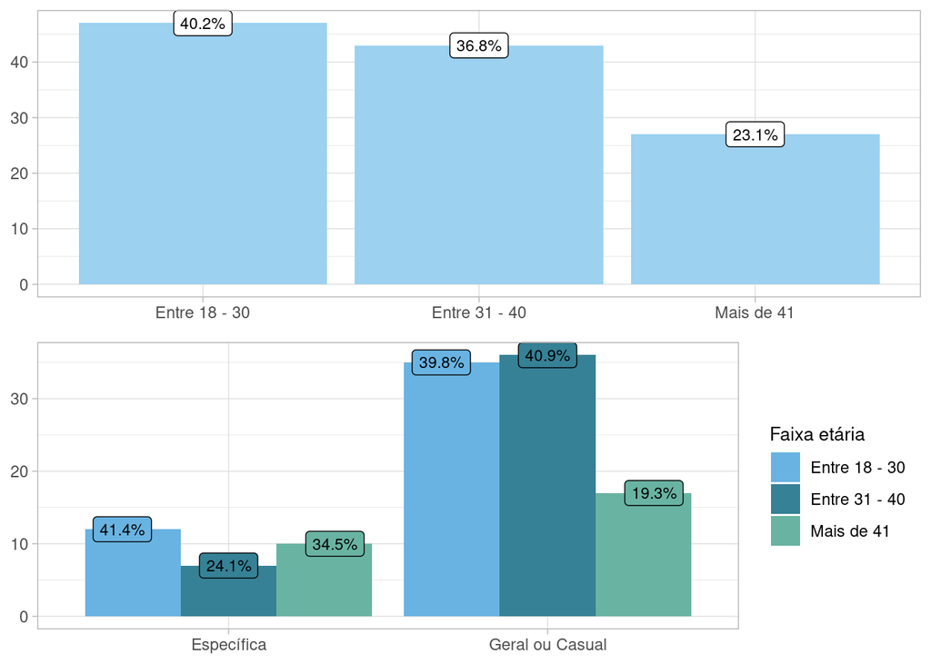

```
##
##  Pearson's Chi-squared test
##
## data:  banco$Grupo and banco$Idade
## X-squared = 3.8569, df = 2, p-value = 0.1454
```

### Gráfico 4: Escolaridade por grupo

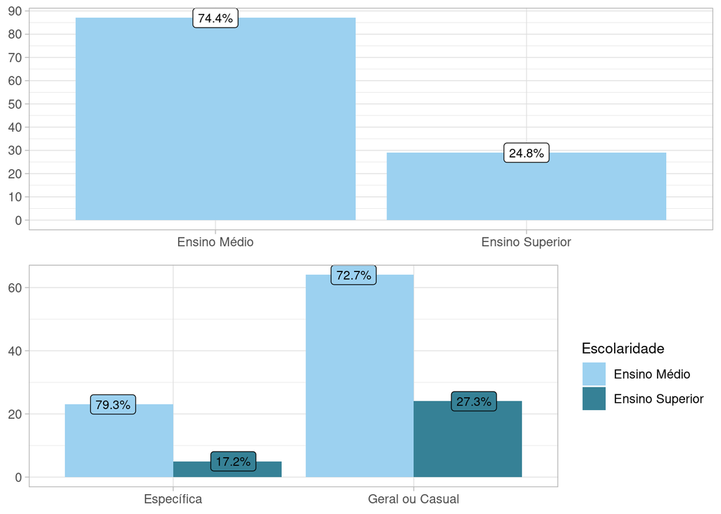

```
##
##  Pearson's Chi-squared test with Yates' continuity correction
##
## data:  banco$Grupo and banco$Escolaridade
## X-squared = 0.56494, df = 1, p-value = 0.4523
```

### Gráfico 5: Região de residência por grupo

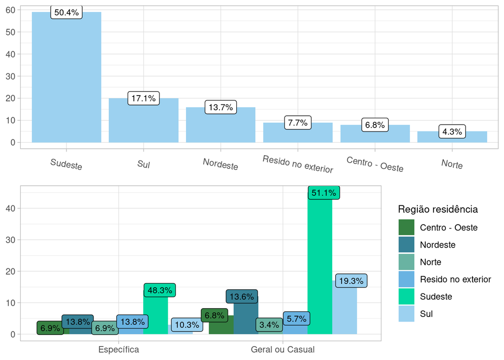

```
##
##  Pearson's Chi-squared test
##
## data:  banco$Grupo and banco$`Região residência`
## X-squared = 3.5498, df = 5, p-value = 0.6159
```

### Gráfico 6: Frequência de consumo audiovisual por grupo

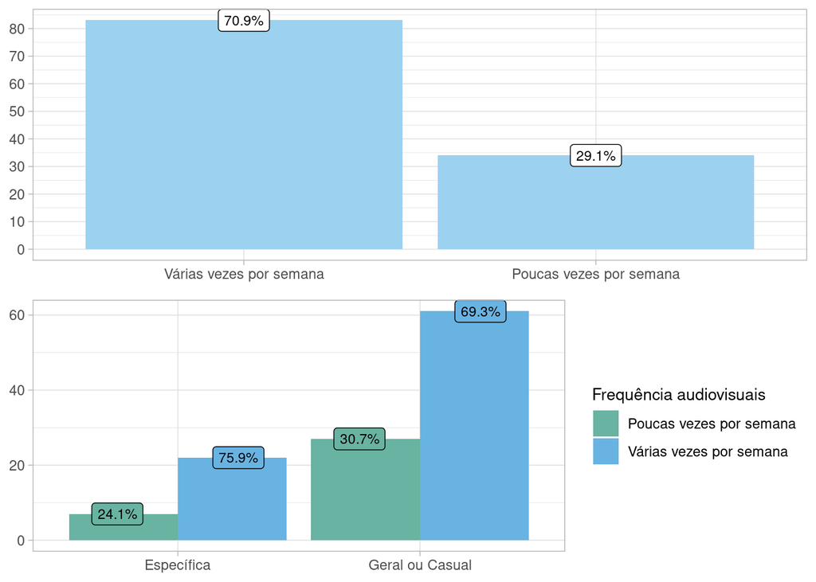

```
##
##  Pearson's Chi-squared test with Yates' continuity correction
##
## data:  banco$Grupo and banco$`Frequência audiovisuais`
## X-squared = 0.19125, df = 1, p-value = 0.6619
```

### Gráfico 7: Assinatura streaming por grupo

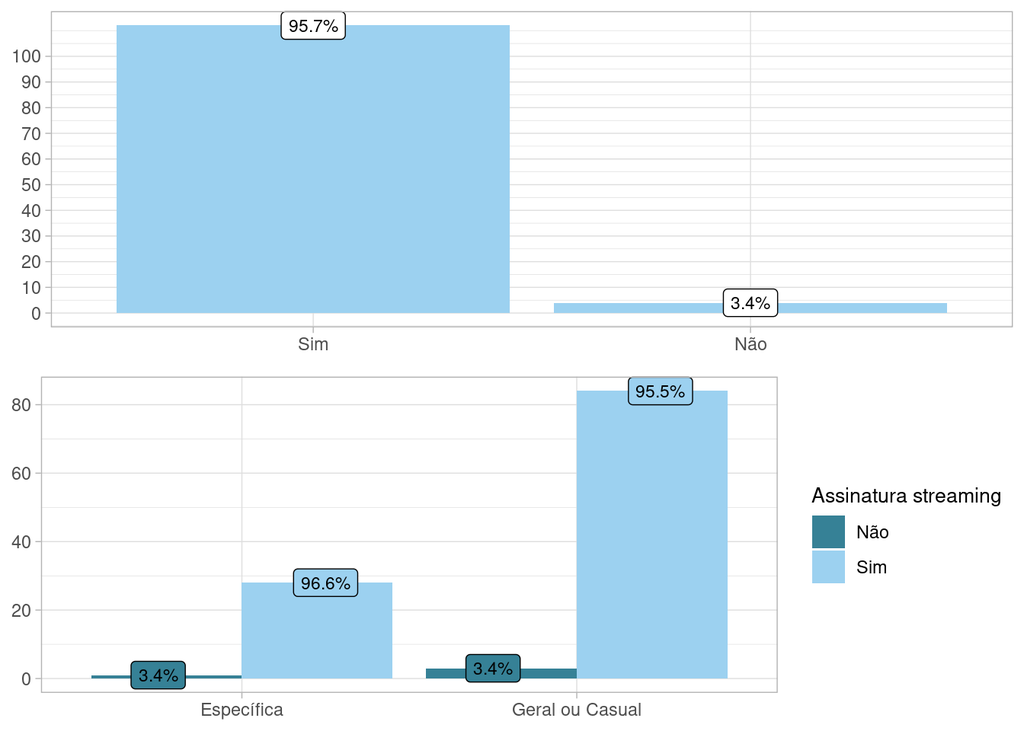

```
##
##  Pearson's Chi-squared test
##
## data:  banco$Grupo and banco$`Assinatura streaming`
## X-squared = 0, df = 1, p-value = 1
```

### Gráfico 8: Motivação da viagem por grupo

[figure not shown]

```
##
##  Pearson's Chi-squared test
##
## data:  banco$Grupo and banco$Motivação
## X-squared = 4.2453, df = 3, p-value = 0.2362
```

### Gráfico 9: Locais visitados estavam de acordo com os retratados em produção audiovisual por grupo

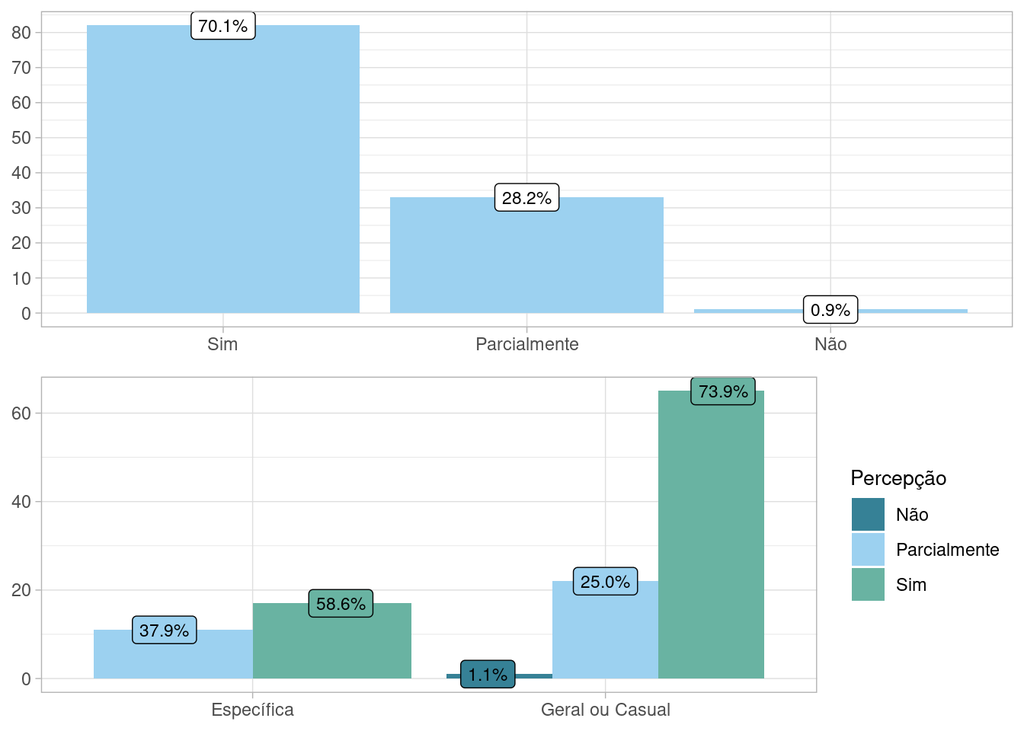

```
##
##  Pearson's Chi-squared test
##
## data:  banco$Grupo and banco$Percepção
## X-squared = 2.3616, df = 2, p-value = 0.307
```

### Gráfico 10: Companhia da viagem por grupo

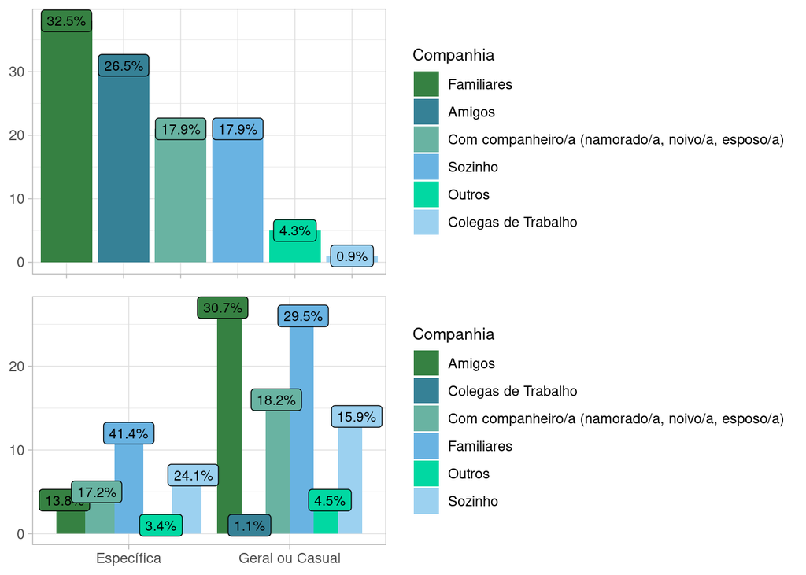

```
##
##  Pearson's Chi-squared test
##
## data:  banco$Grupo and banco$Companhia
## X-squared = 4.5132, df = 5, p-value = 0.4781
```

### Gráfico 11: Satisfação com viagem induzida pelo audiovisual por grupo

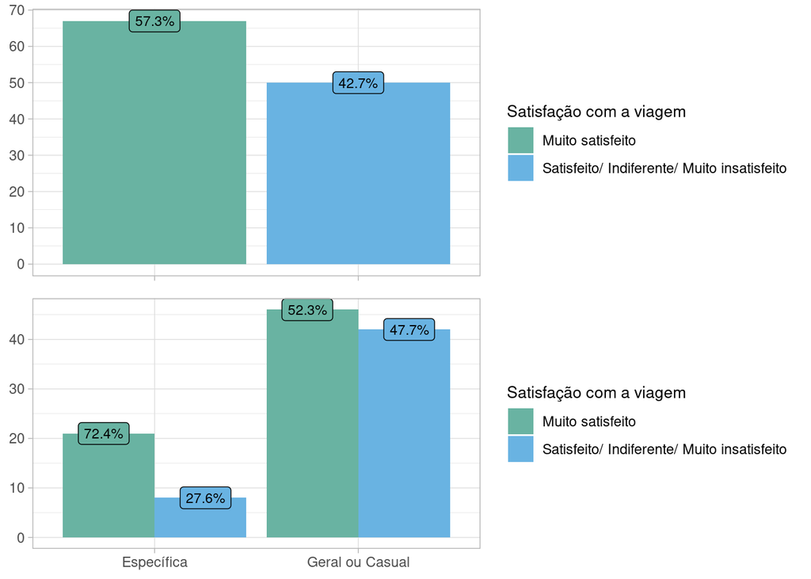

```
##
##  Pearson's Chi-squared test with Yates' continuity correction
##
## data:  banco$Grupo and banco$Satisfação
## X-squared = 2.8395, df = 1, p-value = 0.09197
```

### Gráfico 12: Realizar outra viagem pelo audiovisual por grupo

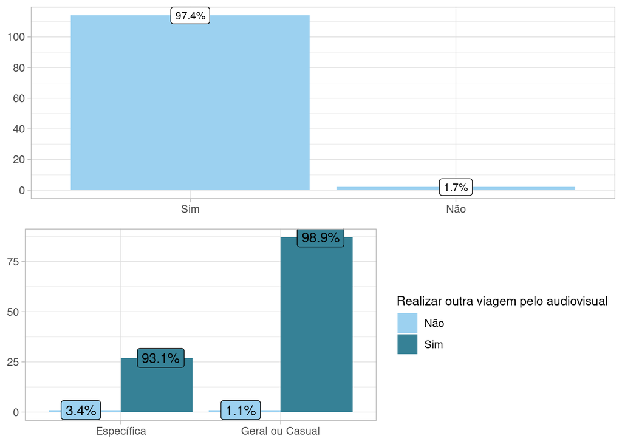

```
##
##  Pearson's Chi-squared test with Yates' continuity correction
##
## data:  banco$Grupo and banco$`Realizar outra viagem pelo audiovisual`
## X-squared = 0.00082593, df = 1, p-value = 0.9771
```

### Gráfico 13: Consumo de produção audiovisual

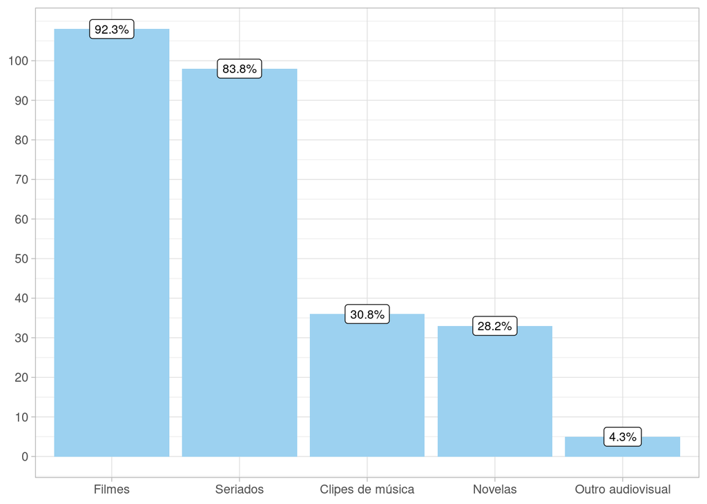

Entre os que citaram “Outro audiovisual”, descreveram: documentários, curtas, propagandas criativas, produtores de conteúdo nas redes sociais.

### Gráfico 14: Turistas que assistem filmes por grupo

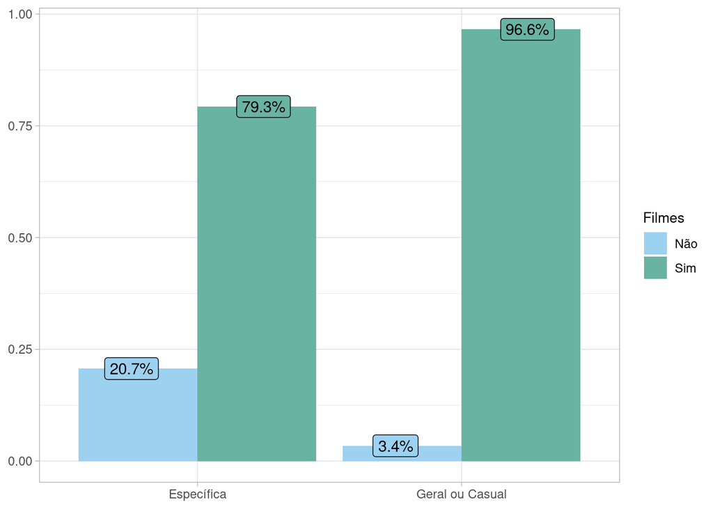

```
##
##  Pearson's Chi-squared test with Yates' continuity correction
##
## data:  data[, 1] and data[, 2]
## X-squared = 6.9008, df = 1, p-value = 0.008616
```

### Gráfico 15: Turistas que assistem novelas por grupo

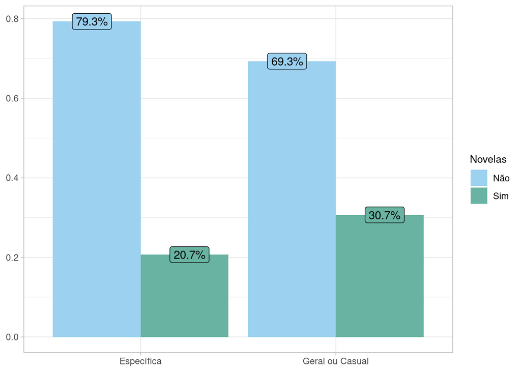

```
##
##  Pearson's Chi-squared test with Yates' continuity correction
##
## data:  data[, 1] and data[, 3]
## X-squared = 0.63861, df = 1, p-value = 0.4242
```

### Gráfico 16: Turistas que assistem seriados por grupo

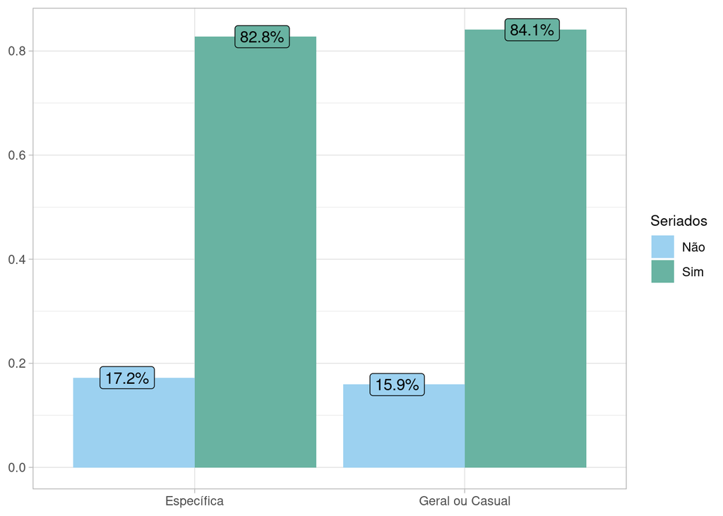

```
##
##  Pearson's Chi-squared test with Yates' continuity correction
##
## data:  data[, 1] and data[, 4]
## X-squared = 1.0733e-30, df = 1, p-value = 1
```

### Gráfico 17: Turistas que assistem clipes de música por grupo

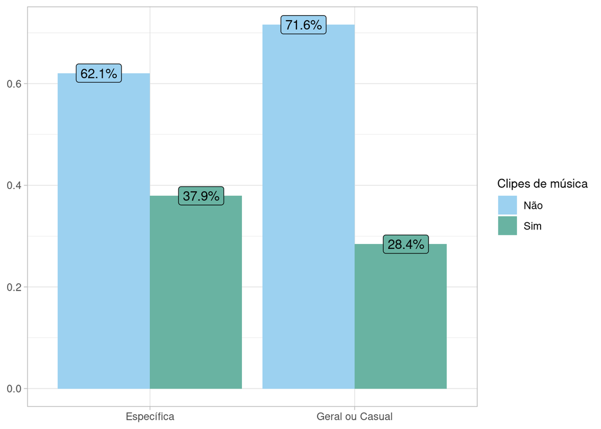

```
##
##  Pearson's Chi-squared test with Yates' continuity correction
##
## data:  data[, 1] and data[, 5]
## X-squared = 0.53519, df = 1, p-value = 0.4644
```

### Gráfico 18: Turistas que assistem outro produto audiovisual por grupo

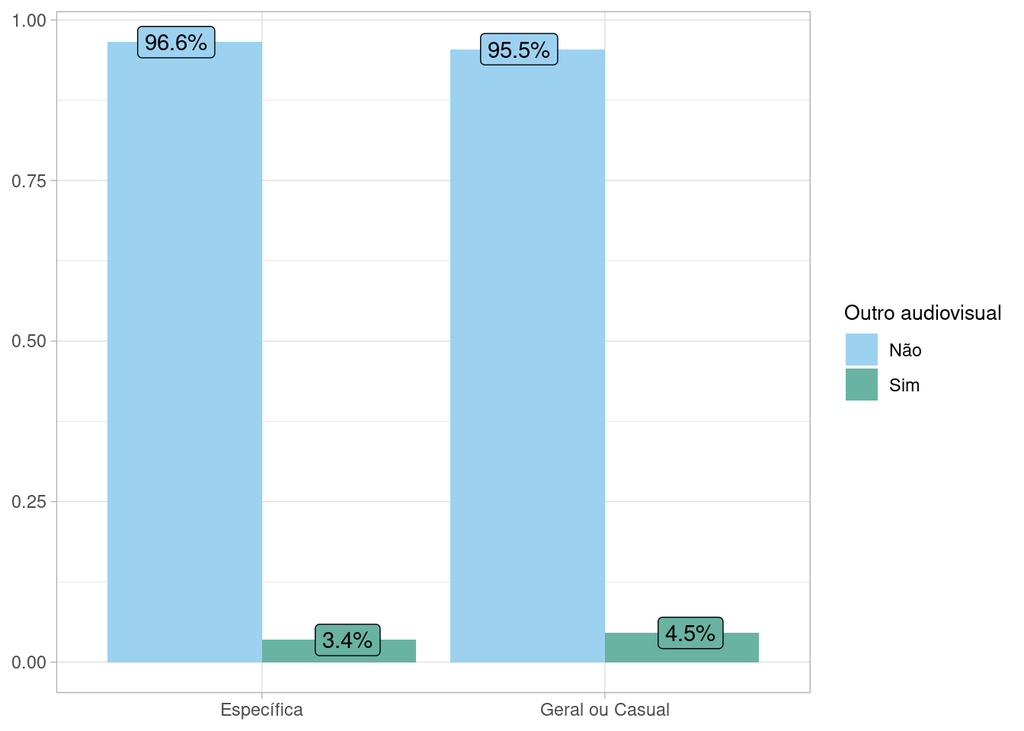

```
##
##  Pearson's Chi-squared test with Yates' continuity correction
##
## data:  data[, 1] and data[, 6]
## X-squared = 8.4629e-31, df = 1, p-value = 1
```

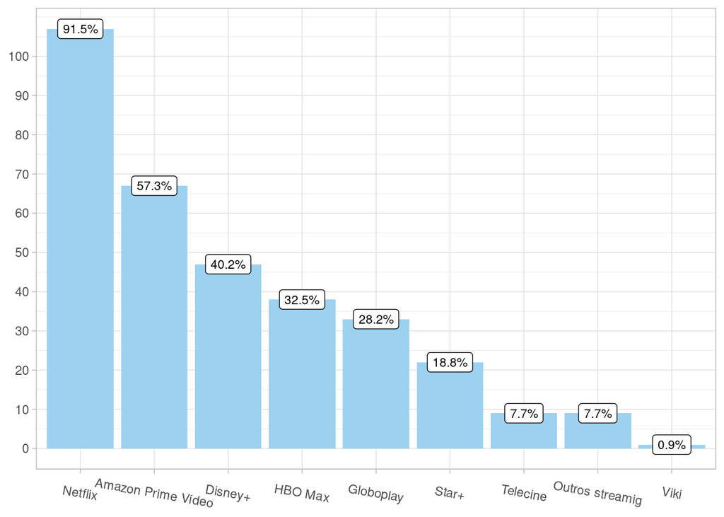

Entre os que citaram “Outros streaming”, descreveram: Pluto TV, Apple TV, Hulu, My Família TV.

### Gráfico 20: Turistas que assinam Netflix por grupo

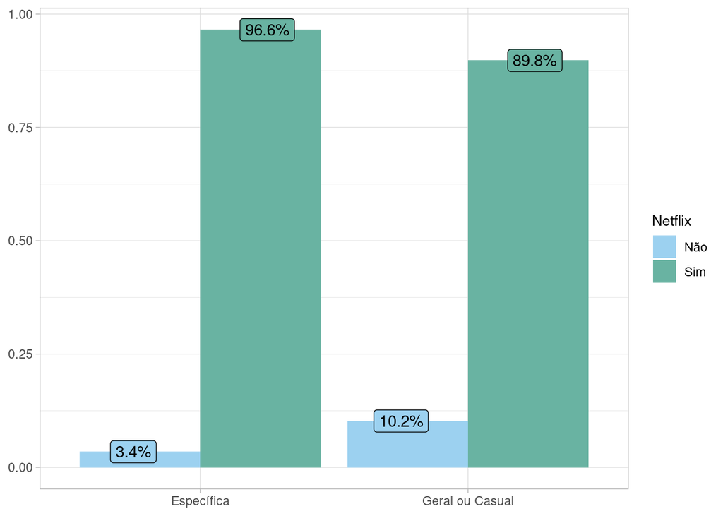

```
##
##  Pearson's Chi-squared test with Yates' continuity correction
##
## data:  data[, 1] and data[, 2]
## X-squared = 0.56174, df = 1, p-value = 0.4536
```

### Gráfico 21: Turistas que assinam Globoplay por grupo

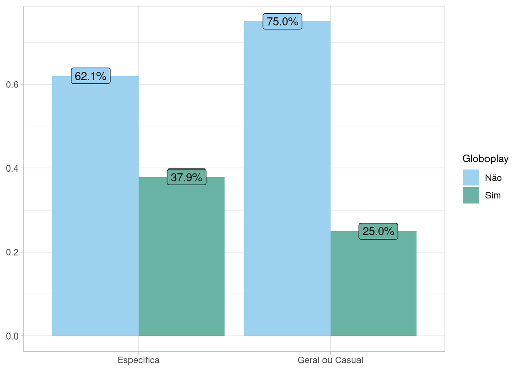

```
##
##  Pearson's Chi-squared test with Yates' continuity correction
##
## data:  data[, 1] and data[, 3]
## X-squared = 1.2191, df = 1, p-value = 0.2695
```

### Gráfico 22: Turistas que assinam Amazon Prime Video por grupo

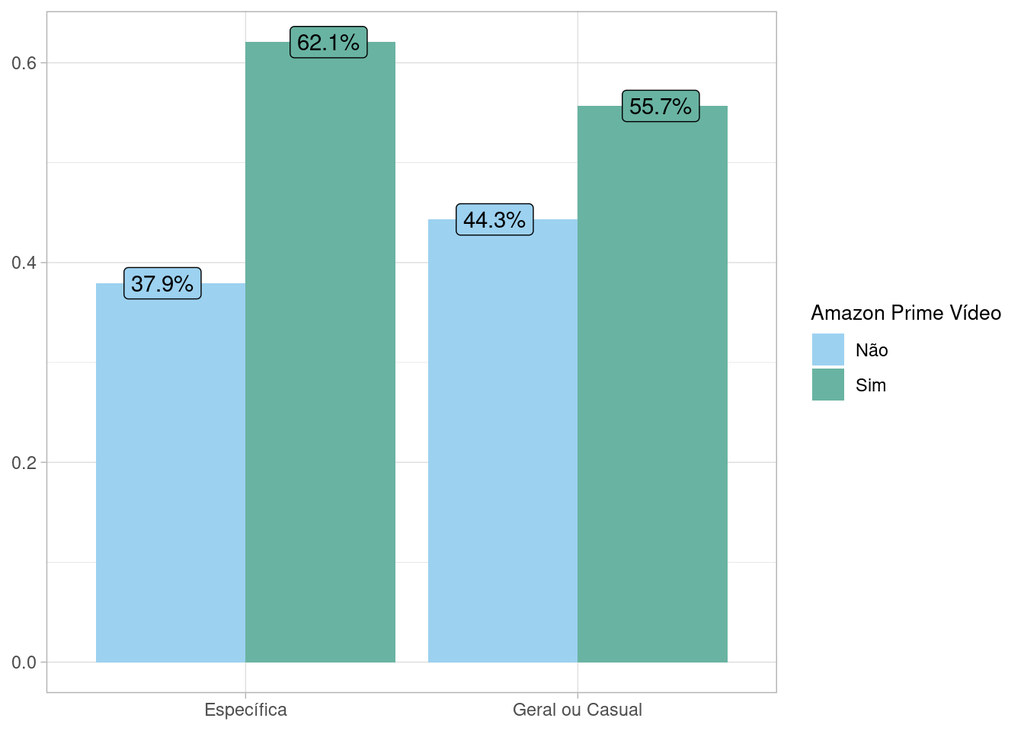

```
##
##  Pearson's Chi-squared test with Yates' continuity correction
##
## data:  data[, 1] and data[, 4]
## X-squared = 0.14945, df = 1, p-value = 0.6991
```

### Gráfico 23: Turistas que assinam HBO Max por grupo

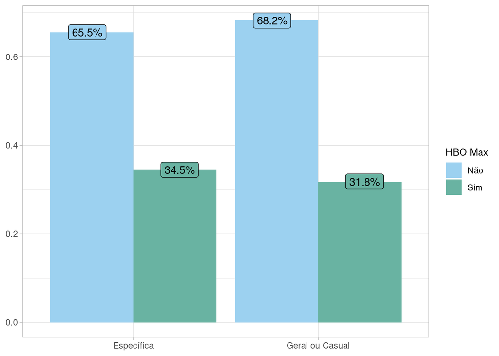

```
##
##  Pearson's Chi-squared test with Yates' continuity correction
##
## data:  data[, 1] and data[, 5]
## X-squared = 0.0013783, df = 1, p-value = 0.9704
```

### Gráfico 24: Turistas que assinam Disney+ por grupo

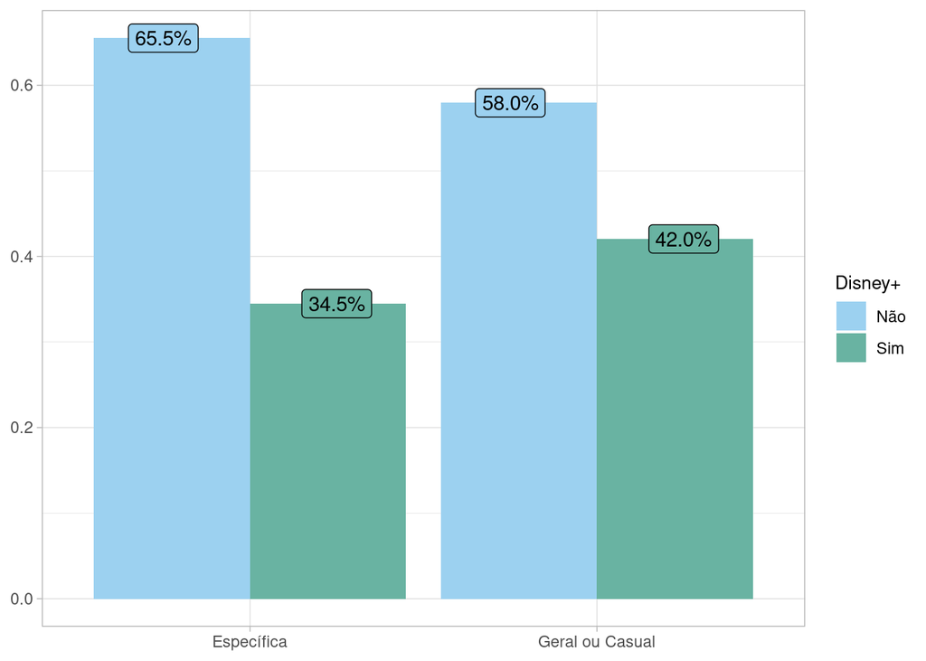

```
##
##  Pearson's Chi-squared test with Yates' continuity correction
##
## data:  data[, 1] and data[, 6]
## X-squared = 0.25209, df = 1, p-value = 0.6156
```

### Gráfico 25: Turistas que assinam Telecine por grupo

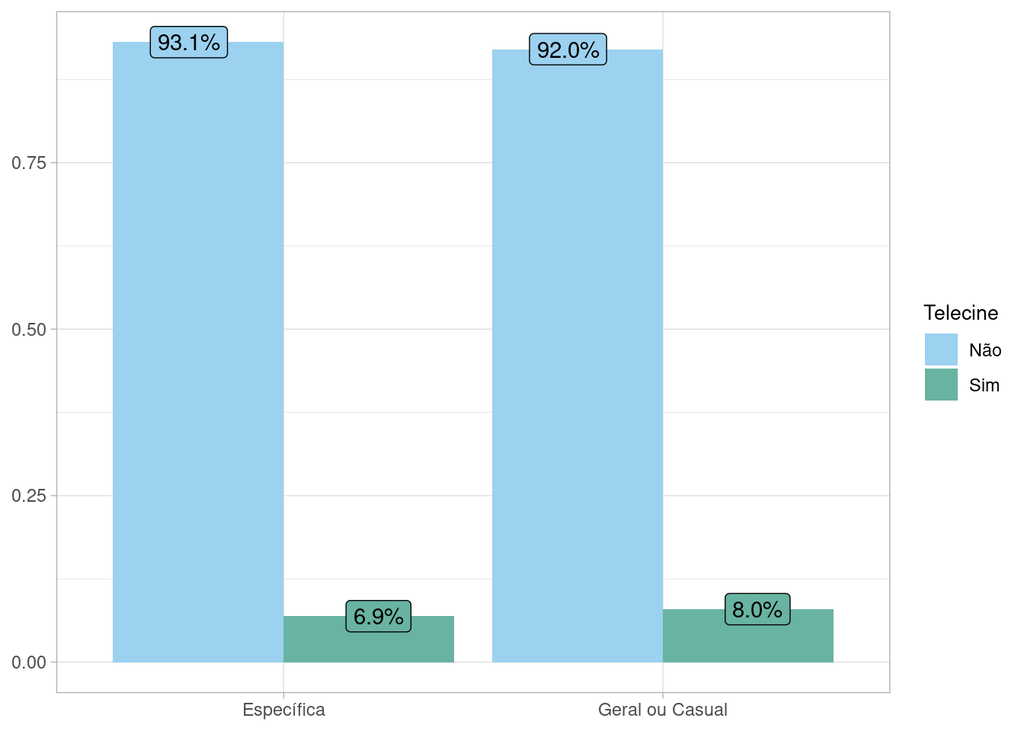

```
##
##  Pearson's Chi-squared test with Yates' continuity correction
##
## data:  data[, 1] and data[, 7]
## X-squared = 1.2226e-29, df = 1, p-value = 1
```

### Gráfico 26: Turistas que assinam Star+ por grupo

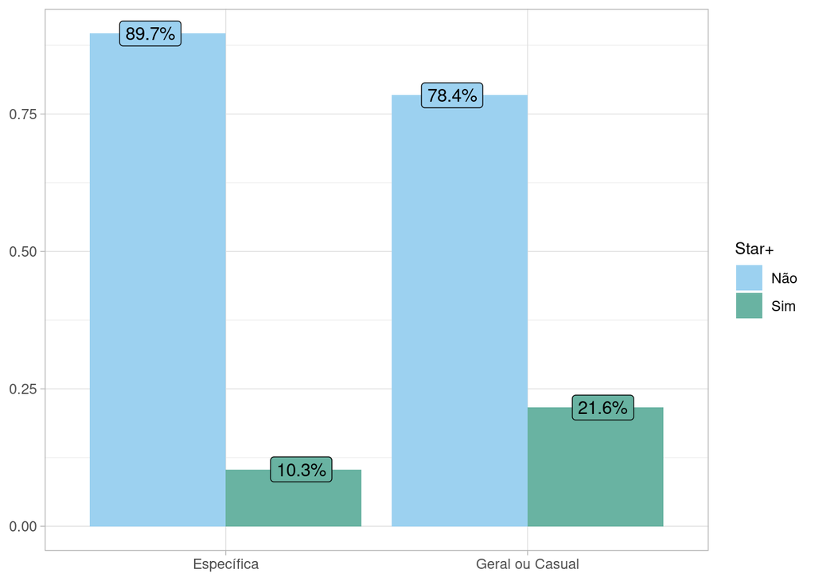

```
##
##  Pearson's Chi-squared test with Yates' continuity correction
##
## data:  data[, 1] and data[, 8]
## X-squared = 1.1453, df = 1, p-value = 0.2845
```

### Gráfico 27: Turistas que assinam Viki por grupo

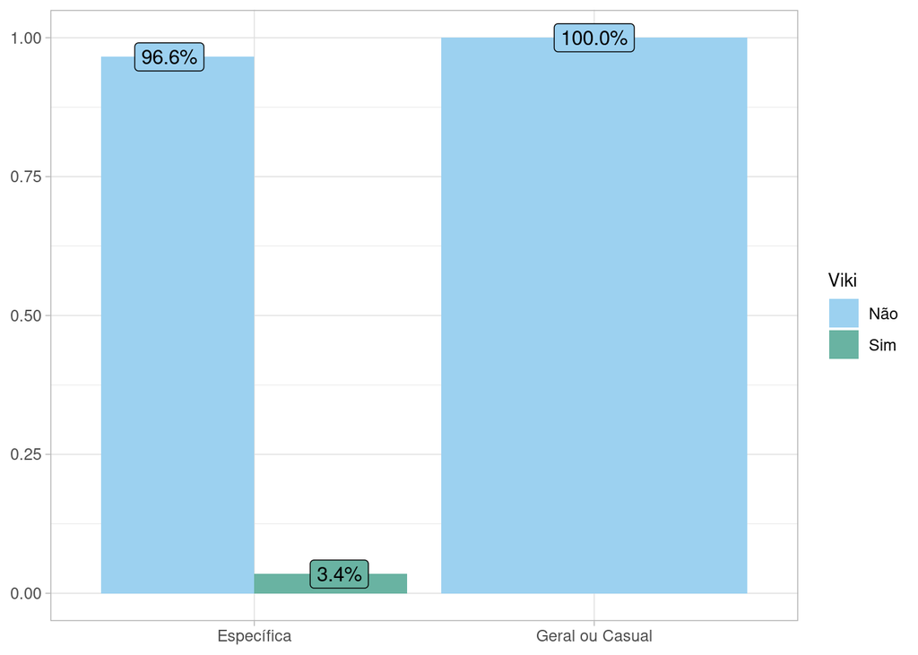

```
##
##  Pearson's Chi-squared test with Yates' continuity correction
##
## data:  data[, 1] and data[, 9]
## X-squared = 0.34395, df = 1, p-value = 0.5576
```

### Gráfico 28: Turistas que assinam Outros streamig por grupo

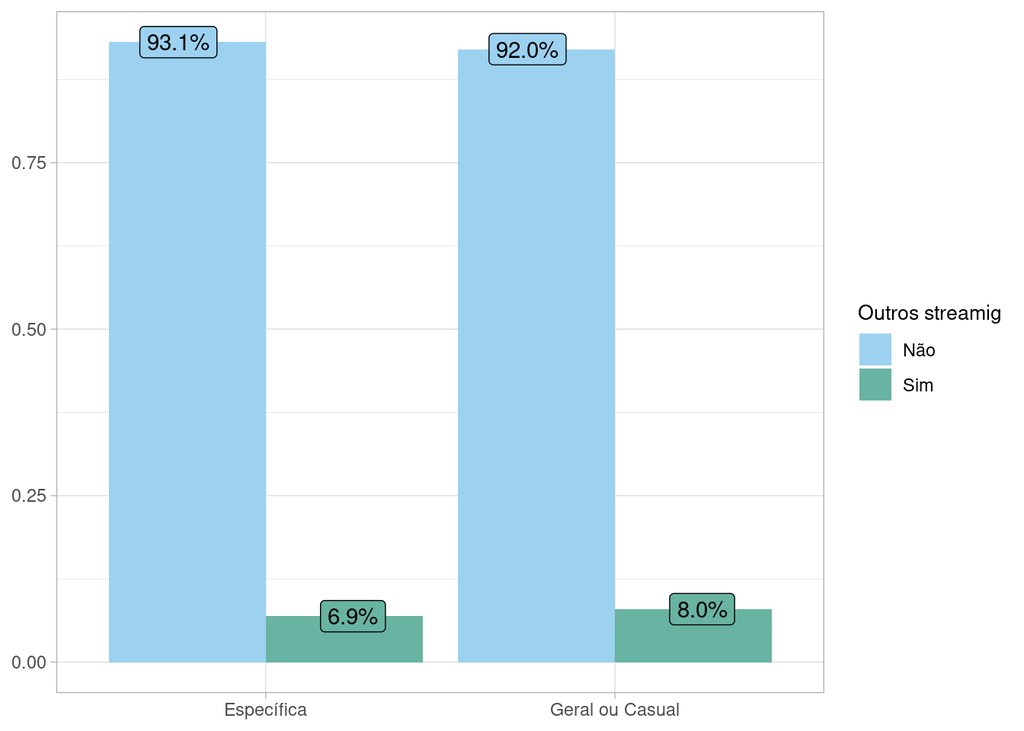

```
##
##  Pearson's Chi-squared test with Yates' continuity correction
##
## data:  data[, 1] and data[, 10]
## X-squared = 1.2226e-29, df = 1, p-value = 1
```

### Gráfico 29: Atividade de lazer relacionada ao audiovisual realizada pelos turistas

[figure not shown]

### Gráfico 30: Turistas que realizaram a atividade Visita a parques, praças e espaços na natureza exibidos na tela por grupo

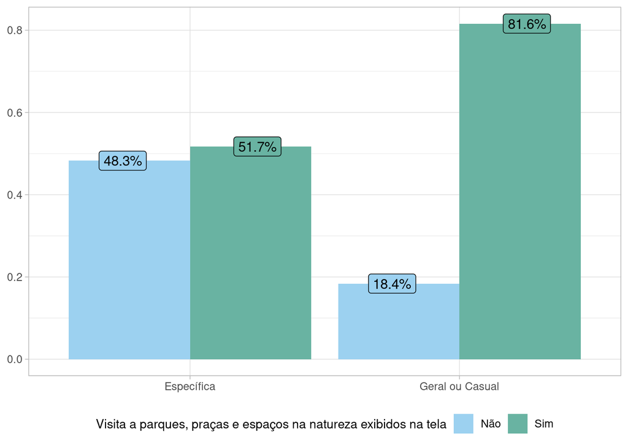

```
##
##  Pearson's Chi-squared test with Yates' continuity correction
##
## data:  data[, 1] and data[, 2]
## X-squared = 8.6326, df = 1, p-value = 0.003302
```

### Gráfico 31: Turistas que realizaram a atividade Visita a Parques temáticos baseados em atrações inspiradas em séries, filmes, etc por grupo

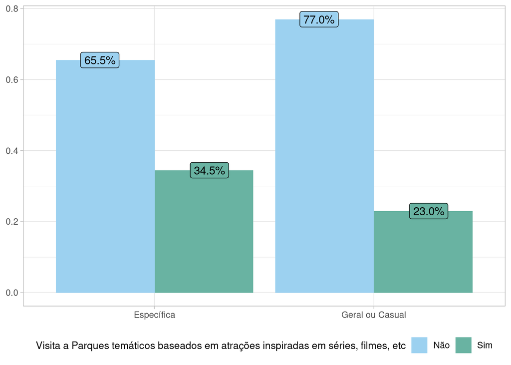

```
##
##  Pearson's Chi-squared test with Yates' continuity correction
##
## data:  data[, 1] and data[, 3]
## X-squared = 0.95917, df = 1, p-value = 0.3274
```

### Gráfico 32: Turistas que realizaram a atividade Visita a cenários internos ou externos onde foram filmadas por grupo

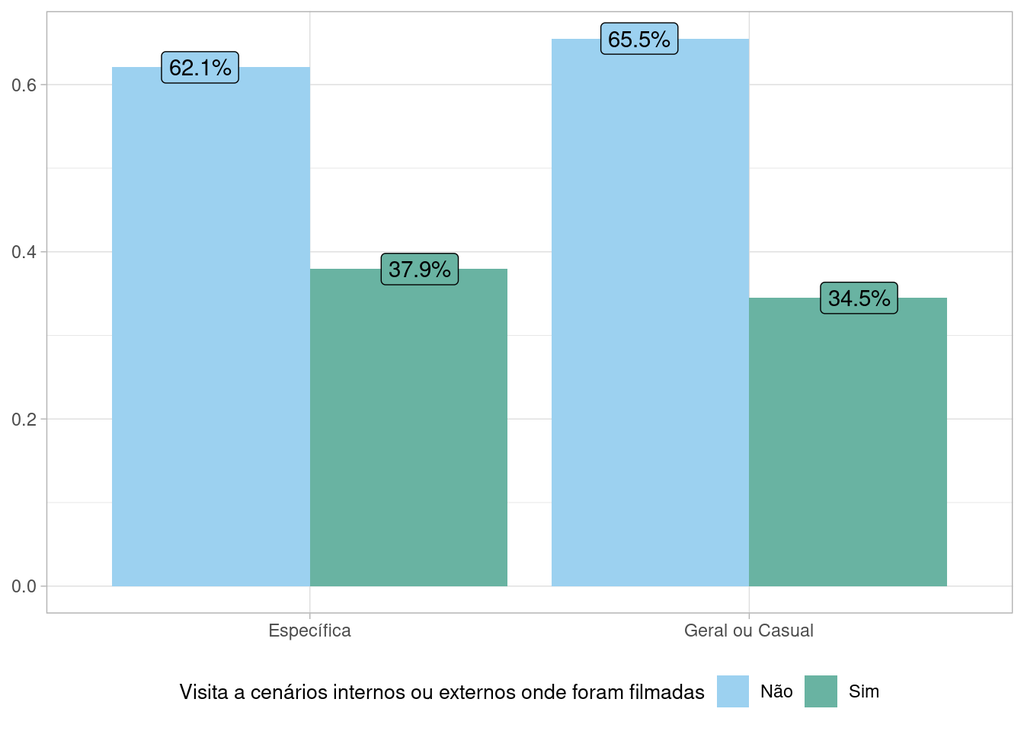

```
##
##  Pearson's Chi-squared test with Yates' continuity correction
##
## data:  data[, 1] and data[, 4]
## X-squared = 0.012575, df = 1, p-value = 0.9107
```